# Exploratory Single-Cell RNA-seq Analysis of PBMC Data Using Seurat

Chitra Karki

2026-04-20

# 1 Introduction

Single-cell RNA sequencing makes it possible to examine gene activity in individual cells, helping researchers understand how different cell types behave within a mixed population. In this study, we use the pbmc_small dataset from the Seurat package as an example to perform a full single-cell analysis workflow.

The goal is to carry out a clear and reproducible analysis that starts with basic data checks and preparation, followed by data scaling, visualization, and grouping of similar cells. We then assign cell identities to these groups. Beyond this core analysis, we also examine how consistent the groupings are, compare the cells to known reference data, and evaluate gene activity patterns linked to specific biological functions. We further identify genes that differ between groups and explore which biological processes they are involved in. Finally, we compare key immune cell groups,myeloid and lymphoid cells,to understand how their functions differ, using statistical tests on sets of related genes.

# 2 Loading Library

```r
rm(list = ls()) # clearning up the R-environment
library(Seurat)
library(tidyverse) # data transformation
library(ggplot2) # visualization
library(patchwork)
library(clustree)# clustering evaluation
library(SingleR)# annotation
library(celldex) # AUCell
library(AUCell) # DGE & enrichment
library(clusterProfiler)
library(org.Hs.eg.db) # Visualization
library(ggpubr)
```

# 3 Loading Data

```r
data("pbmc_small")
df_pbmc = pbmc_small
```

# 4 Exploration

```r
# object type
class(df_pbmc)
```

```
## [1] "Seurat"
## attr(,"package")
## [1] "SeuratObject"
```

```r
# dimension
dim(df_pbmc)
```

```
## [1] 230  80
```

```r
# structure of the seurat object
str(df_pbmc,max.level = 2)
```

```
## Formal class 'Seurat' [package "SeuratObject"] with 13 slots
##   ..@ assays      :List of 1
##   ..@ meta.data   :'data.frame': 80 obs. of  7 variables:
##   ..@ active.assay: chr "RNA"
##   ..@ active.ident: Factor w/ 3 levels "0","1","2": 1 1 1 1 1 1 1 1 1 1 ...
##   .. ..- attr(*, "names")= chr [1:80] "ATGCCAGAACGACT" "CATGGCCTGTGCAT" "GAACCTGATGAACC" "TGACTGGATTCTCA" ...
##   ..@ graphs      :List of 1
##   ..@ neighbors   : list()
##   ..@ reductions  :List of 2
##   ..@ images      : list()
##   ..@ project.name: chr "SeuratProject"
##   ..@ misc        : list()
##   ..@ version     :Classes 'package_version', 'numeric_version'  hidden list of 1
##   ..@ commands    :List of 10
##   ..@ tools       : list()
```

```r
#str(df_pbmc)
```

The class of the pbmc object is Seurat. The pbmc data contains 230 rows (genes) and 80 columns (cells). The Seurat objects (pbmc data set) contains nested lists, data-frames and slots. For clarity the depth of 2 is used.

```r
# meta data
head(df_pbmc@meta.data)
```

```
##                   orig.ident nCount_RNA nFeature_RNA RNA_snn_res.0.8
## ATGCCAGAACGACT SeuratProject         70           47               0
## CATGGCCTGTGCAT SeuratProject         85           52               0
## GAACCTGATGAACC SeuratProject         87           50               1
## TGACTGGATTCTCA SeuratProject        127           56               0
## AGTCAGACTGCACA SeuratProject        173           53               0
## TCTGATACACGTGT SeuratProject         70           48               0
##                letter.idents groups RNA_snn_res.1
## ATGCCAGAACGACT             A     g2             0
## CATGGCCTGTGCAT             A     g1             0
## GAACCTGATGAACC             B     g2             0
## TGACTGGATTCTCA             A     g2             0
## AGTCAGACTGCACA             A     g2             0
## TCTGATACACGTGT             A     g1             0
```

For the first cell total of 70 RNA molecules were detected, with 47 unique RNA molecules or genes. These counts are valuable piece of information for quality check.

```r
# gene names
rownames(df_pbmc)
```

```
##   [1] "MS4A1"         "CD79B"         "CD79A"         "HLA-DRA"
##   [5] "TCL1A"         "HLA-DQB1"      "HVCN1"         "HLA-DMB"
##   [9] "LTB"           "LINC00926"     "FCER2"         "SP100"
##  [13] "NCF1"          "PPP3CC"        "EAF2"          "PPAPDC1B"
##  [17] "CD19"          "KIAA0125"      "CYB561A3"      "CD180"
##  [21] "RP11-693J15.5" "FAM96A"        "CXCR4"         "STX10"
##  [25] "SNHG7"         "NT5C"          "BANK1"         "IGLL5"
##  [29] "CD200"         "FCRLA"         "CD3D"          "NOSIP"
##  [33] "SAFB2"         "CD2"           "IL7R"          "PIK3IP1"
##  [37] "MPHOSPH6"      "KHDRBS1"       "MAL"           "CCR7"
##  [41] "THYN1"         "TAF7"          "LDHB"          "TMEM123"
##  [45] "CCDC104"       "EPC1"          "EIF4A2"        "CD3E"
##  [49] "TMUB1"         "BLOC1S4"       "ACSM3"         "TMEM204"
##  [53] "SRSF7"         "ACAP1"         "TNFAIP8"       "CD7"
##  [57] "TAGAP"         "DNAJB1"        "ASNSD1"        "S1PR4"
```

[output cut: 43 more lines]

The output shows 230 genes and their encodes.

## 4.1 Quality Control Plots

```r
# searching mitochondrial genes starting with MT on gene names
PercentageFeatureSet(df_pbmc,pattern = "^MT-") # mt for mouse
```

[output not shown]

There are no Mitochondrial(MT) gene contents detected. The higher content of MT genes indicates the cell death or the poor health of the cell.

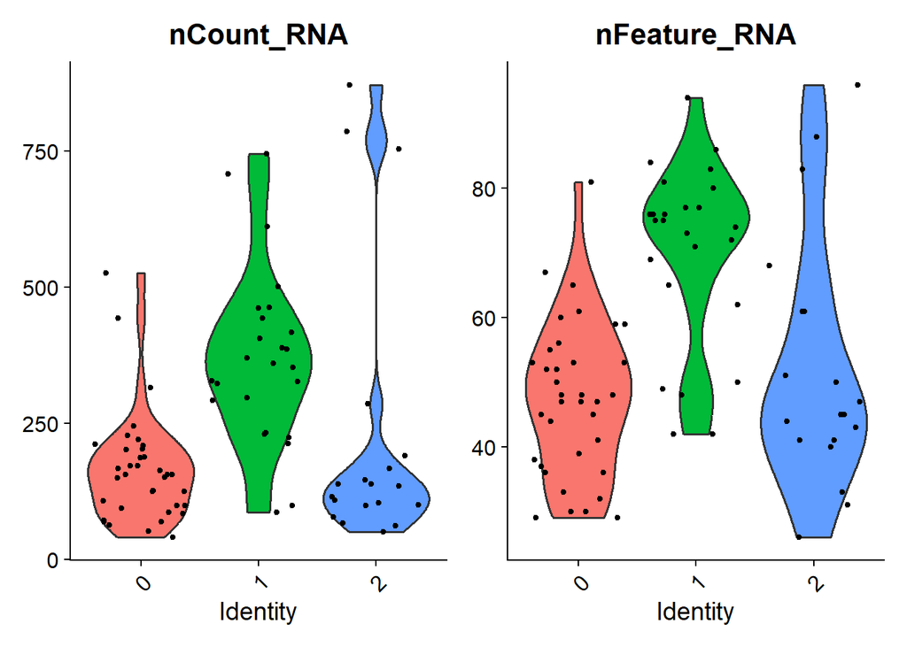

```r
# violin plot for quality check
VlnPlot(pbmc_small,features = c("nCount_RNA", "nFeature_RNA"))
```

There are three cluster in the plot, probably its referencing the “RNA_snn_res.1” column in meta data, containing 3 cluster at resolution 1.

The three point on the cluster 2 are isolated from rest of the members if its clusters. They might need further analysis to detect if they are outliers or droplets.

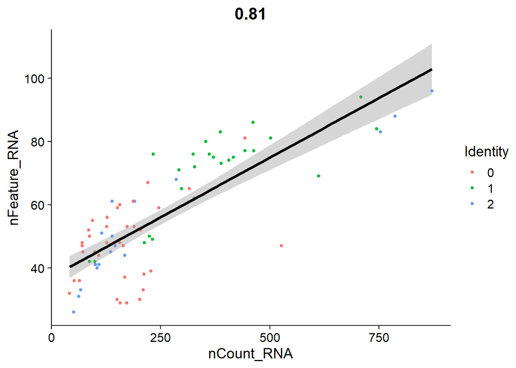

```r
# correlation between ncount_RNA and nFeaature_RNA
FeatureScatter(df_pbmc,feature1 = "nCount_RNA", feature2 = "nFeature_RNA") + geom_smooth(method = "lm", colour = "black")
```

The correlation between the features is 0.81, which is strong. Points at the ends of the linear line might need attention, as the ratio of nCount to nFeatrue is either very low or high in comparison to rest of the data points.

Filters on the features can be applied for the quality control based on the domain knowledge.

## 4.2 Normalization and Feature Selection

The log normalization is performed to normalize the variance of counts of the genes in cells. Default parameter were used for normalization.

```r
df_pbmc = NormalizeData(df_pbmc,normalization.method = "LogNormalize",scale.factor = 10000)

# df_pbmc@assays$RNA$scale.data # scaled data location inside the seurate object
```

After the normalization, the next step in the workflow is the identification of highly variable features (genes). Highly expressed genes will have significant variance across the cells.

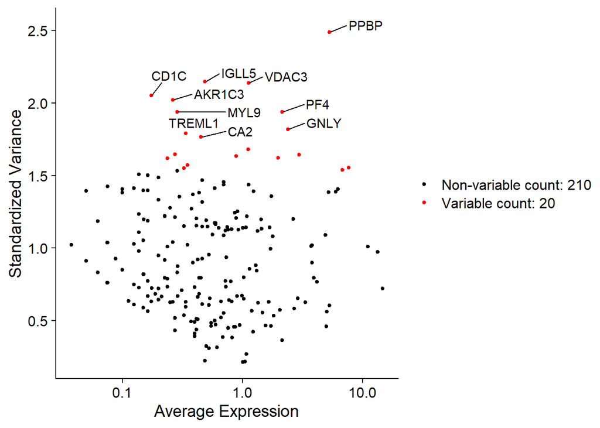

```r
df_pbmc = FindVariableFeatures(df_pbmc, selection.method = "vst", nfeatures = 20)

#?FindVariableFeatures
# vst: variance stabilizing transformation (loess; statistical method under the hood)

# checking the selected features
top20 = VariableFeatures(df_pbmc)

# plotting the selected features with to 10-genes labeling
p1 = VariableFeaturePlot(df_pbmc) # without label
p2 = LabelPoints(plot = p1, points = top20[1:10], repel = TRUE)

# plot
p2
```

In this analysis, highly variable top 20 genes were picked.

## 4.3 Scaling and PCA

The linear transformation (scaling), which is to provide similar weights to the data points, is performed before dimensional reduction methods like PCA. The scaling shifts the mean and variance of the expression level of genes across cells to 0 and 1.

```r
#?ScaleData
all_genes = rownames(df_pbmc)
df_pbmc = ScaleData(df_pbmc,features = all_genes )
# by default features = variable features; 20 genes as selected in above step.
```

The scaled data is used for linear dimensional reduction: principal component analysis (PCA) in this study, providing principle components and their contribution on explaining the variability in gene expressions.

```r
df_pbmc = RunPCA(df_pbmc, features = VariableFeatures(df_pbmc))

# Examine and visualize PCA results a few different ways
print(df_pbmc[["pca"]], dims = 1:5, nfeatures = 5)
```

```
## PC_ 1
## Positive:  SDPR, PF4, PPBP, TUBB1, CA2
## Negative:  HLA-DPB1, HLA-DQA1, S100A9, S100A8, GNLY
## PC_ 2
## Positive:  HLA-DPB1, HLA-DQA1, S100A8, S100A9, CD1C
## Negative:  GNLY, AKR1C3, VDAC3, PGRMC1, TUBB1
## PC_ 3
## Positive:  S100A9, S100A8, RP11-290F20.3, AKR1C3, PARVB
## Negative:  HLA-DQA1, CD1C, IGLL5, HLA-DPB1, RUFY1
## PC_ 4
## Positive:  IGLL5, RP11-290F20.3, VDAC3, PPBP, TUBB1
## Negative:  CD1C, AKR1C3, S100A8, GNLY, HLA-DPB1
## PC_ 5
## Positive:  MYL9, PARVB, IGLL5, TREML1, AKR1C3
## Negative:  VDAC3, RP11-290F20.3, RUFY1, CD1C, HLA-DQA1
```

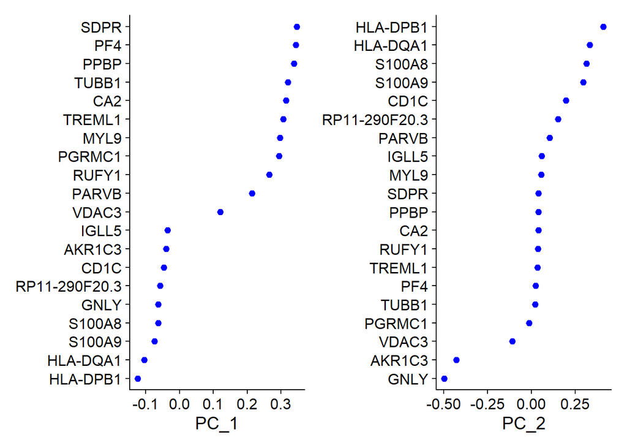

```r
# loadings for 2 principal components
VizDimLoadings(df_pbmc, dims = 1:2, reduction = "pca")
```

The loading plot for PC_1 and PC_2 helps to identify important genes on the principal components and their direction on pca plot: same direction suggests some level of similarity in the gene expression and opposite direction hints their dis-similarity.

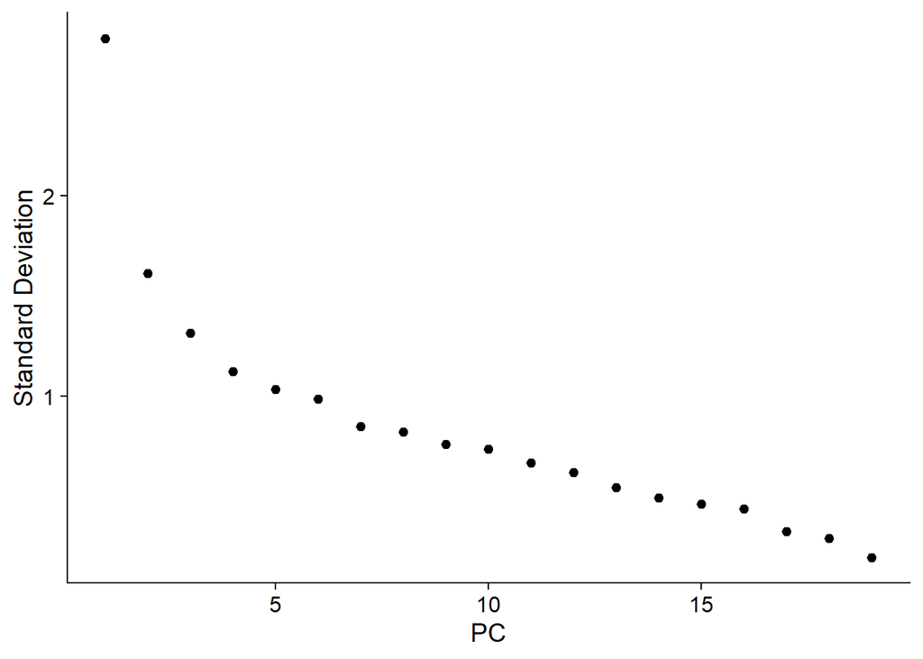

```r
# elbow plot gives the total variance explained by each principal components.
ElbowPlot(df_pbmc)
```

The elbow plot is useful to determine the number of principal components that captures desired level cumulative variability. PC_1 captures majority of the signal almost 3-sd and sharply decline for other PCs thereafter. Roughly around 10th PC the curve starts to flat or linear. Hence, 10 PCs might be enough to capture most cumulative variability in the gene expression.

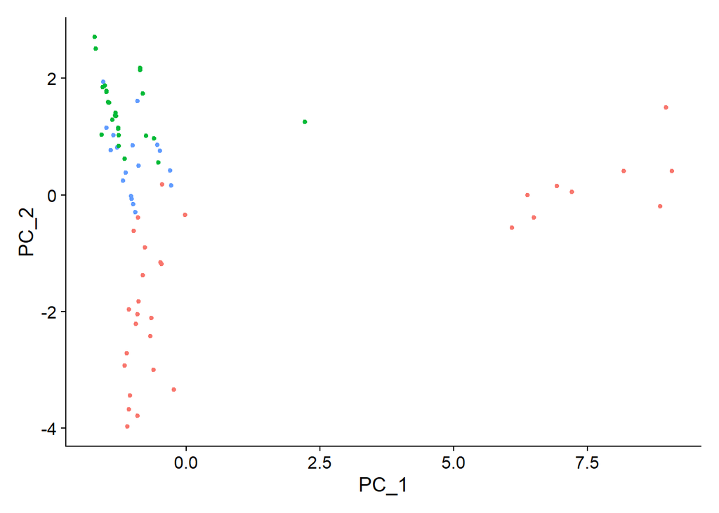

```r
DimPlot(df_pbmc, reduction = "pca") + NoLegend()
```

The most variability is captured by PC_1, where data points are widely extended out (evident by the presence of tiny cluster on the far side of PC_1). As compared to PC_1, PC2 is capturing less variability which is evident by the less variability of the date points along PC_2. Moreover, there is overlap between green and the blue data points, on the positive side of the PC_2, which suggests more PCs are required for clear separation. On the other hand, there are red points towards the negative side of the PC_2, which suggests green genes are different then red genes in some respect (type or function).

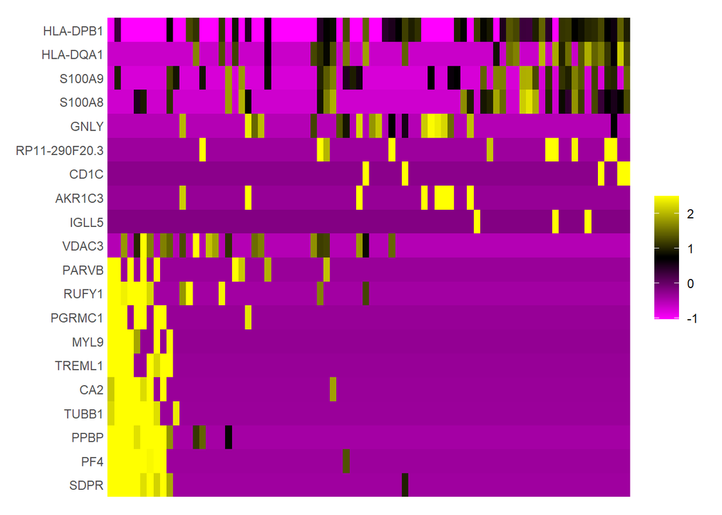

```r
# balanced = TRUE indicated the same number of cells are utilized on either side of the PC_1 (positive and negative)
DimHeatmap(df_pbmc, dims = 1, cells = 80, balanced = TRUE, fast = FALSE)
```

The heat map shows the level of gene expression across the cells. The bottom left has the yellow patch, so these genes (CA2, TUBB1, PPBP, PF4, SDRP, etc.) have high level of expression across the cells, which shows similarity in them.

Similarly, the top right corner of the heat map shows patches of mid range expression of genes.

More PCs heat maps can be generated by adjusting dims argument in the `DimHeatmap` function, for instance `dims = 1:10` will give us 10 heat maps. Further, elbow plot might come handy in this case to determine the number of PCs to utilize.

## 4.4 Clustering and UMAP

Utilizing 10 PCs as suggested by elbow plot, a Shared Nearest Neighbor (SNN) graph is constructed using `FindNeighbors` function. This calculates the closeness of the cells using the local neighbors in the reduced dimension space with out distorting the underlying data structure. The Louvian algorithm was then applied with the function `Findcluster` to identify the highly connected clusters of the cells. In order to have a comparison across resolution, 0 to 1 with step size 0.1 was used.

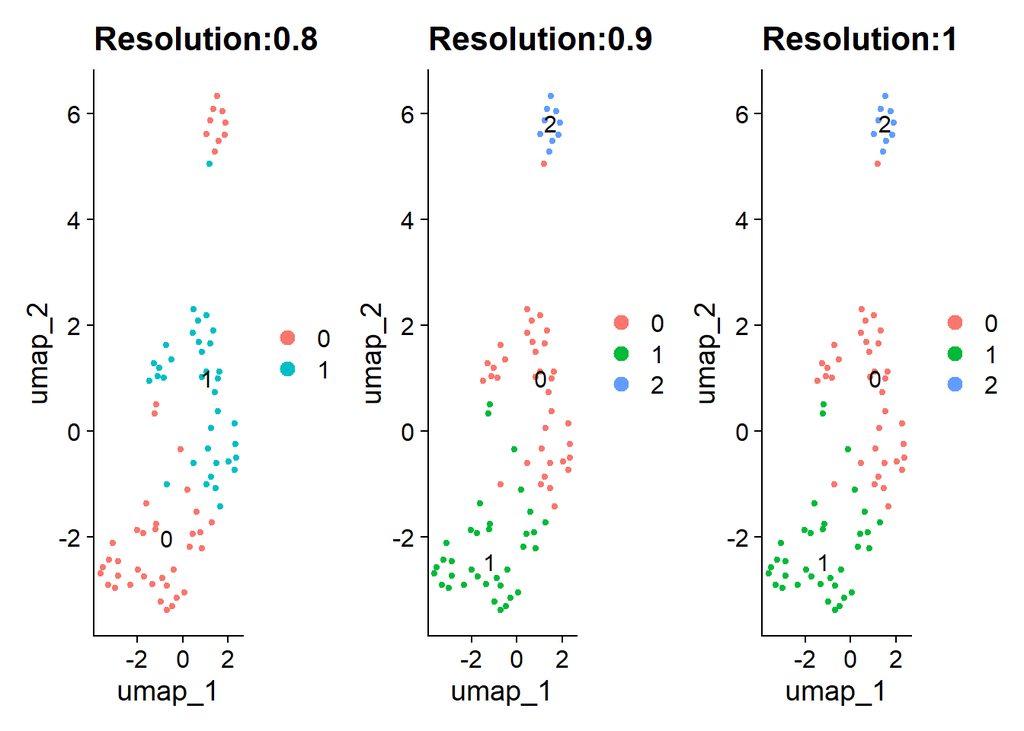

```r
df_pbmc = FindNeighbors(df_pbmc, dims = 1:10)
df_pbmc = FindClusters(df_pbmc, resolution = seq(0.1,1,0.1),verbose = FALSE)
df_pbmc =  RunUMAP(df_pbmc, dims = 1:10)
#df_pbmc = RunTSNE(df_pbmc,dims = 1:10,perplexity=10) # errors with this
#DimPlot(df_pbmc,reduction = "tsne",label = TRUE)

Idents(df_pbmc) <- "RNA_snn_res.0.8"
p08 = DimPlot(df_pbmc, reduction = "umap",label = TRUE) + ggtitle("Resolution:0.8")

Idents(df_pbmc) <- "RNA_snn_res.0.9"
p09 = DimPlot(df_pbmc, reduction = "umap",label = TRUE) + ggtitle("Resolution:0.9")

Idents(df_pbmc) <- "RNA_snn_res.1"
p1 = DimPlot(df_pbmc, reduction = "umap",label = TRUE) + ggtitle("Resolution:1")

p08 + p09 + p1
```

# 5 Clustree Analysis (Resolution Selection)

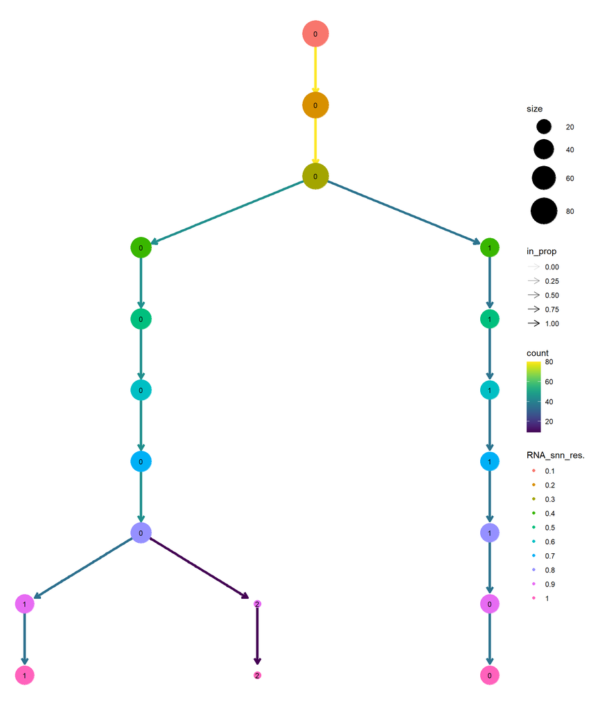

```r
clustree(df_pbmc, prefix = "RNA_snn_res.")
```

The vertical arrows between the resolution 0.9 and 1 indicates the cluster stability, with no further branch outs. This suggests 0.9 is the best resolution.

# 6 Cell Type Annotation

## 6.1 SingleR (Reference-Based)

The annotation of the cells are performed with correlation-based annotation tool `SingleR` referencing the Human Primary Cell Atlas library.

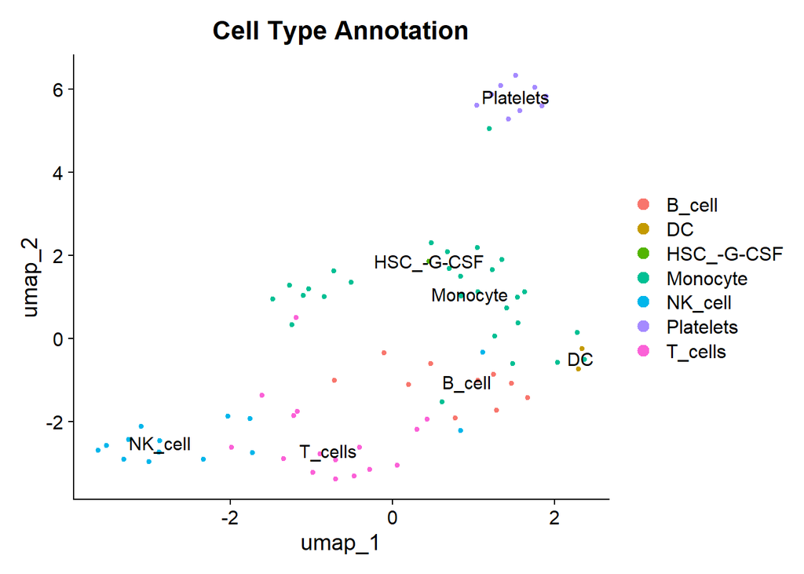

```r
# referencing library
ref = HumanPrimaryCellAtlasData()

# annotation prediction by SingleR: Spearman correlation
pred = SingleR(test = as.matrix(df_pbmc@assays$RNA$data),
                ref = ref,
                labels = ref$label.main)

# annotation labels
df_pbmc$SingleR_label = pred$labels

# annotation plot
DimPlot(df_pbmc, group.by = "SingleR_label", label = TRUE) +
  ggtitle("Cell Type Annotation")
```

Interestingly, isolated cluster in PCA/UMA analysis is being annotated as patelets (cluster-2).

## 6.2 AUCell (Gene Set-Based)

For cellular identity, `AUCell` is utilized to perform gene set scoring. This rank based method calculated the Area Under the Curve (AUC) to predefined gene clusters. Three gene sets were selected utilizing gold standard markers derived form established immunological frameworks (Abbas et al., 2021; Mabbott et al., 2013),

- lymphoid (CD3D, CD3E, CD4, CD8A)
- myeloid (LYZ, S100A8, S100A9)
- platelets (PPBP, PF4)

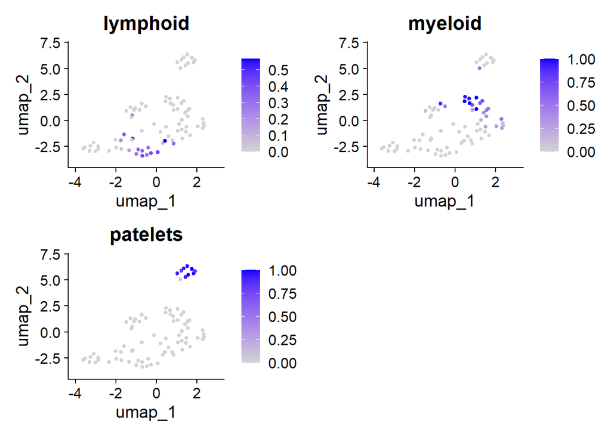

```r
# categorizing the genes
gene_cat = list( lymphoid = c("CD3D", "CD3E", "CD4", "CD8A"),
                 myeloid = c("LYZ", "S100A8", "S100A9"),
                 patelets = c("PPBP","PF4"))

# count matrix
exprMatrix = GetAssayData(df_pbmc, layer = "counts")
cells_rankings = AUCell_buildRankings(exprMatrix, plotStats = FALSE)
cells_AUC = AUCell_calcAUC(gene_cat, cells_rankings)
auc_matrix = t(getAUC(cells_AUC)) # transposing
df_pbmc = AddMetaData(df_pbmc, auc_matrix)

#plot
FeaturePlot(df_pbmc, features = c("lymphoid", "myeloid","patelets"))
```

Plots shows, lymphoid, myeloid, and platelets cells are distributed in distinct regions of the UMAP.

## 6.3 Myeloid vs Lymphoid vs Patelets Asignment

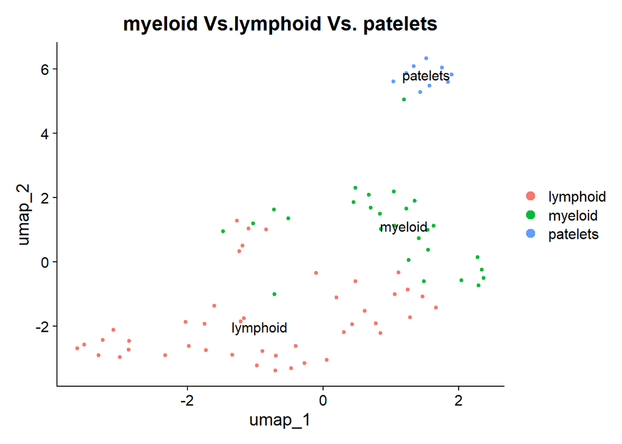

```r
# specifying the labels in the meta data
df_pbmc$celltype =
  case_when(df_pbmc$patelets > df_pbmc$myeloid & df_pbmc$patelets > df_pbmc$lymphoid ~ "patelets",
  df_pbmc$myeloid > df_pbmc$lymphoid ~ "myeloid",
  TRUE ~ "lymphoid"
)

#plot
DimPlot(df_pbmc, group.by = "celltype", label = TRUE) +
  ggtitle("myeloid Vs.lymphoid Vs. patelets")
```

# 7 Differential Gene Exploration (DGE)

DEG is a statistical comparison used for identifying genes that are expressed differently across groups of cells. It measures the fold change (how much higher the expression is in one cluster vs others) and p-values(the statistical confidence of differential gene expression across cells).

## 7.1 Cluster-Level Marker

```r
# cluster marker indentification
cluster_markers = FindAllMarkers(df_pbmc, only.pos = TRUE)

# top three genes in the each cluster, act as bio-markers
cluster_markers %>%
  group_by(cluster) %>%
  arrange(p_val_adj) %>%
  slice_head(n = 3)
```

```
## # A tibble: 9 × 7
## # Groups:   cluster [3]
##      p_val avg_log2FC pct.1 pct.2 p_val_adj cluster gene
##      <dbl>      <dbl> <dbl> <dbl>     <dbl> <fct>   <chr>
## 1 4.43e-10       4.03 0.889 0.432  1.02e- 7 0       LYZ
## 2 5.63e-10       3.40 0.806 0.114  1.30e- 7 0       TYMP
## 3 2.30e- 9       3.35 0.833 0.295  5.29e- 7 0       CST3
## 4 4.38e- 8       5.23 0.6   0.044  1.01e- 5 1       LCK
## 5 2.65e- 7       5.80 0.571 0.067  6.09e- 5 1       CD3D
## 6 3.01e- 7       5.00 0.571 0.067  6.93e- 5 1       CD7
## 7 8.48e-19      13.7  1     0      1.95e-16 2       GP9
## 8 2.82e-17      10.6  1     0.014  6.48e-15 2       PF4
## 9 2.82e-17       9.50 1     0.014  6.48e-15 2       GNG11
```

The table displays top three gene in each cluster which are highly expressed and statistically significant in expression across the clusters.

Moreover, they serve as the markers for their respective cluster, for instance LYZ, TYMP and CSTS are markers for cluster 0 (myeloid). Cluster 1 and cluster 2 are lymphoid and patelets, and their markers are (LCK, CD3D,CD7) and (GP9, PF4,GNG11), respectively.

The `avg_log2FC` (fold change) value for LYZ gene in cluster is 4.03, which means it is expressed $2^{4.03}$ (nearly 16) times more strongly in cluster 0 then in all other cells.

## 7.2 Myeloid vs Lymphoid

```r
Idents(df_pbmc) = df_pbmc$celltype
dge_ml <- FindMarkers(df_pbmc, ident.1 = "myeloid", ident.2 = "lymphoid")
head(dge_ml)
```

```
##               p_val avg_log2FC pct.1 pct.2    p_val_adj
## LYZ    8.229092e-13   4.171462 1.000 0.455 1.892691e-10
## TYMP   1.125705e-10   2.977833 0.963 0.182 2.589121e-08
## CST3   3.227002e-10   3.005846 0.963 0.273 7.422104e-08
## S100A8 6.680673e-10   6.049272 0.815 0.114 1.536555e-07
## FCGRT  1.415402e-08   2.911478 0.815 0.114 3.255424e-06
## LGALS2 2.315950e-08   3.580834 0.704 0.045 5.326685e-06
```

# 8 Pathway Enrichment Analysis

The functional enrichment analysis of the significant genes were performed across the cluster.

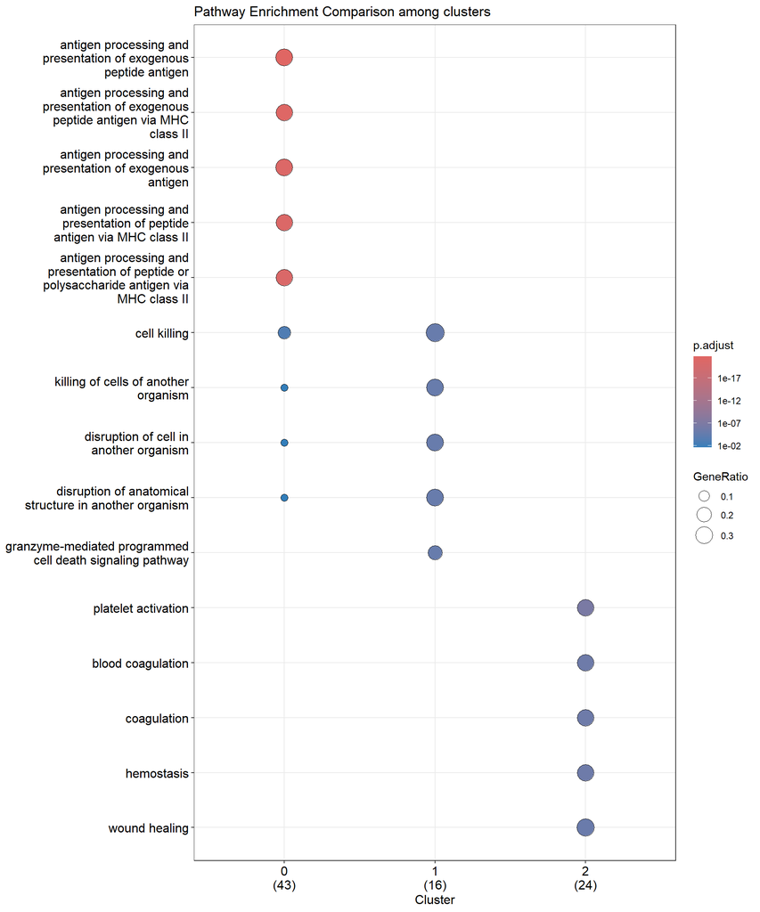

```r
# selection of significant genes <0.05
genes_to_test <- cluster_markers %>%
  filter(p_val_adj < 0.05) %>% # significance level 0.05
  dplyr::select(gene, cluster)

# symbol conversion from human readable gene names to their ID
entrez_df <- bitr(genes_to_test$gene, fromType="SYMBOL", toType="ENTREZID", OrgDb=org.Hs.eg.db)

# merge back to keep cluster assignments
genes_with_clusters <- merge(genes_to_test, entrez_df, by.x="gene", by.y="SYMBOL")

# comparative enrichment
comp_go <- compareCluster(ENTREZID ~ cluster,
                          data = genes_with_clusters,
                          fun = "enrichGO",
                          OrgDb = org.Hs.eg.db,
                          ont = "BP")

# 3. Visualize
dotplot(comp_go) + ggtitle("Pathway Enrichment Comparison among clusters")
```

From the dot plot following are observed,

- cluster 0 has functionality of MHC-II mediated antigen presentation
- cluster 1 exhibits cell killing
- cluster 2 exhibits coagulation and hemostasis

Cluster 2 has non-overlapping functions while cluster 0 and 1 share some functionalists. (43), (16) and (24) represent number of genes in the marker lists that were successfully mapped to the `GO` database.

# 9 Visualization of Significant Genes

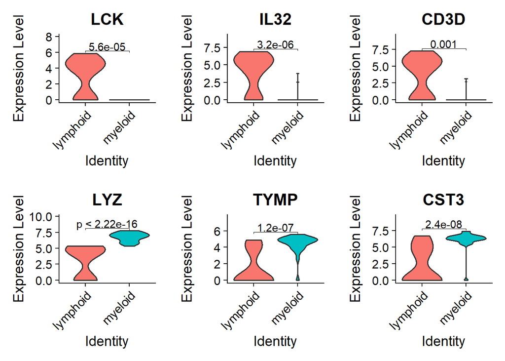

```r
# how many genes to display per cluster
n_genes = 3

# slicing tow n_genes per cluster
top_genes =
  dge_ml %>%
  rownames_to_column(var = "gene") %>%
  mutate(cluster = ifelse(avg_log2FC > 0, "myeloid", "lymphoid")) %>%
  group_by(cluster) %>%
  arrange(p_val_adj) %>%
  slice_head(n = n_genes) %>%
  ungroup() %>%
  dplyr::select(gene) %>%
  unlist()

#Violin Plot
# statistical comparision  of lymphoid, vs myeloid
comp_clust = list( c("lymphoid", "myeloid") )

#subset with out patelets
df_subset = subset(df_pbmc, idents = c("lymphoid", "myeloid"))

# function to generate plots with statistical test
plot_list = lapply(top_genes, function(gene) {
  VlnPlot(df_subset, features = gene, group.by = "celltype", pt.size = 0) +
    # statistical test for the comparison
    stat_compare_means(comparisons = comp_clust,
                       method = "wilcox.test",
                       label = "p.format") +
    # adjust y-axis limit to make space forp-value
    ylim(0, max(FetchData(df_pbmc, vars = gene)) + 2) +
    NoLegend()
})

# final figure
CombinePlots(plots = plot_list, ncol = 3)
```

The top three genes in lymphoid and myeloid clusters are displayed along with p-values from Wilcoxon rank-sum tests. The statistical confidence is high in their differential expression among the clusters.

# 10 Module Scoring (Myeloid Vs. Lymphoid)

Module scoring identifies what a cell is doing, its functionality or pathway. The top enriched functions of myeloid (antigen processing and presentation of exogenous peptide antigen) and lymphoid (killing of cells of another organism ) are extracted for module scoring to test whether the pathway is significantly enriched.

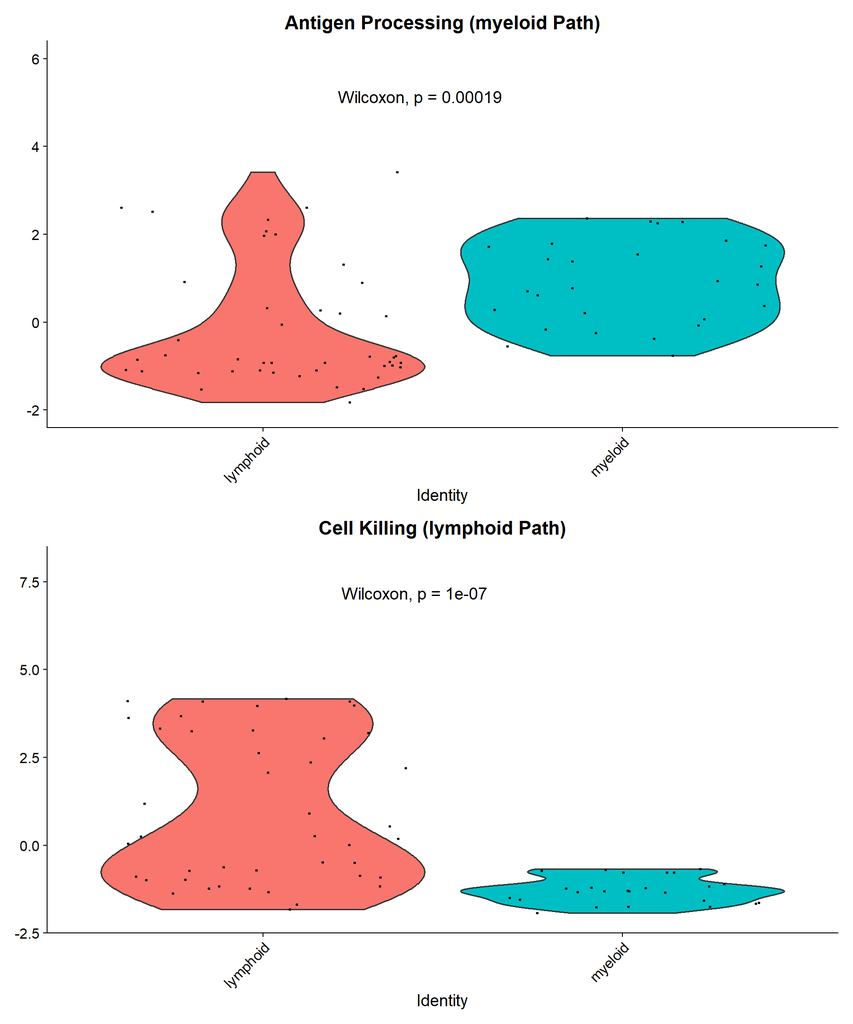

```r
# geting top term genes for myeloid (cluster 0) and lymphoid (cluster 1)
results = comp_go@compareClusterResult

# myeloid pathway:top term:cluster 0
myeloid_term = results %>%
  filter(cluster == 0) %>%
  slice(1)

#gene names
myeloid_genes = bitr(strsplit(myeloid_term$geneID, "/")[[1]],
                      fromType="ENTREZID", toType="SYMBOL", OrgDb=org.Hs.eg.db)$SYMBOL

# lymphoid pathway:top term;cluster 1)
lymphoid_term = results %>%
  filter(cluster == 1) %>%
  slice(1)

# gene names
lymphoid_genes = bitr(strsplit(lymphoid_term$geneID, "/")[[1]],
                       fromType="ENTREZID", toType="SYMBOL", OrgDb=org.Hs.eg.db)$SYMBOL

# module score calculation
df_pbmc = AddModuleScore(df_pbmc,
                          features = list(myeloid_genes, lymphoid_genes),
                          name = "PathwayScore",
                          ctrl = 5)

# rename metadata columns for clarity
colnames(df_pbmc@meta.data)[which(colnames(df_pbmc@meta.data) == "PathwayScore1")] <- "myeloid_Pathway"
colnames(df_pbmc@meta.data)[which(colnames(df_pbmc@meta.data) == "PathwayScore2")] <- "lymphoid_Pathway"

# subset on myeloid vs lymphoid
df_subset <- subset(df_pbmc, idents = c("lymphoid", "myeloid"))

# plot:myeloid pathway
p1 <- VlnPlot(df_subset, features = "myeloid_Pathway", pt.size = 0.5) +
  stat_compare_means(method = "wilcox.test", label.y = 5, label.x = 1.3) +
  labs(title = "Antigen Processing (myeloid Path)") +
  ylim(-2, 6) + NoLegend()

# Plot:lymphoid Pathway Activity
p2 <- VlnPlot(df_subset, features = "lymphoid_Pathway", pt.size = 0.5) +
  stat_compare_means(method = "wilcox.test", label.y = 7, label.x = 1.3) +
  labs(title = "Cell Killing (lymphoid Path)") +
  ylim(-2, 8) + NoLegend()

# combined plot
p1 + p2
```

The enriched pathway in myeloid and lymphoid cells are statistically significant. The significance of the lymphoid pathway is easy to observe through the violin plots (bottom panel), while for myeloid pathway (top panel), the lymphoid graph may seem tall but myeloid cluster have higher distribution points greater then the lymphoid cluster points.

# 11 Summary

In this study, a complete analysis of single-cell RNA sequencing data was carried out using the pbmc_small dataset. The workflow covered key steps such as data preparation, visualization, grouping of similar cells, producing results, followed by more detailed analyses.

Different methods used to label cell types identifying three main groups of cells: lymphoid, myeloid, and platelet cells. These groups were clearly separated in clusters when visualized, which supported the reliable analysis.

Analysis of gene differences between groups identified strong marker genes that differentiated heterogenisity of the cell type. Further exploration of biological functions showed clear differences between cell types, such as immune signaling roles in myeloid cells and cell-killing activity in lymphoid cells. These functions were confirmed using gene set–based scoring.

Overall, this work presents a clear and reproducible approach to analyzing single-cell RNA-seq data. By combining cell grouping, cell identification, and functional analysis, this study showed how single cell data can be utilized to understand the biological functions of diversed cells and genes.

# 12 References

- Abbas, A. K., Lichtman, A. H., & Pillai, S. (2021). Cellular and Molecular Immunology. 10th Edition. Elsevier Health Sciences.
- Aibar, S., et al. (2017). “SCENIC: single-cell regulatory network inference and clustering.” Nature Methods, 14(11), 1083–1086.
- Aran, D., et al. (2019). “Reference-based analysis of single-cell transcriptomes with SingleR.” Nature Immunology, 20(2), 163–172.
- Mabbott, N. A., et al. (2013). “An expression atlas of human primary cells: inference of gene function utilizing microarray data.” BMC Genomics, 14(1), 632.
- Satija, R., Farrell, J. A., Gennert, D., Schier, A. F., & Regev, A. (2015). “Spatial reconstruction of single-cell gene expression data.” Nature Biotechnology, 33(5), 495–502.
- Yu, G., Wang, L., Han, Y., & He, Q. (2012). “clusterProfiler: an R package for comparing biological themes among gene clusters.” OMICS: A Journal of Integrative Biology, 16(5), 284–287.